# MARKET BASKET ANALYSIS

Vivek Pruthi,Murali Korrapati, Jyothi Pulimamidi

August 17, 2017

## An attempt to understand the customer preferences:

This project is an attempt to understand the transactional datasetby exploring the dataset further and then try to find out the patterns in the transactions and identify the association Rules. Identifying the association among the parts of transaction can help us understand the effect one part can make on the other part. Once the if x then y scenario is understood, interested party can tweek the purchasing,sales offers, position of item , inventory and even discontinue few categories to help the bottomline of the company.

We will use the “Groceries” dataset . The Groceries data set contains 1 month (30 days) of real-world point-of-sale transaction data from a typical local grocery outlet. The data set contains 9835 transactions and the items are aggregated to 169 items.

Before starting the project we will load the requisite libraries :

```r
library(arules)
```

```r
library(arulesViz)
library(ggplot2)
library(dplyr)
library(plotrix)
```

let’s first check the data provided to get an overview:

```r
data("Groceries")
class(Groceries)
```

```
## [1] "transactions"
## attr(,"package")
## [1] "arules"
```

```r
str(Groceries)
```

```
## Formal class 'transactions' [package "arules"] with 3 slots
##   ..@ data       :Formal class 'ngCMatrix' [package "Matrix"] with 5 slots
##   .. .. ..@ i       : int [1:43367] 13 60 69 78 14 29 98 24 15 29 ...
##   .. .. ..@ p       : int [1:9836] 0 4 7 8 12 16 21 22 27 28 ...
##   .. .. ..@ Dim     : int [1:2] 169 9835
##   .. .. ..@ Dimnames:List of 2
##   .. .. .. ..$ : NULL
##   .. .. .. ..$ : NULL
##   .. .. ..@ factors : list()
##   ..@ itemInfo   :'data.frame':  169 obs. of  3 variables:
##   .. ..$ labels: chr [1:169] "frankfurter" "sausage" "liver loaf" "ham" ...
##   .. ..$ level2: Factor w/ 55 levels "baby food","bags",..: 44 44 44 44 44 44 44 42 42 41 ...
##   .. ..$ level1: Factor w/ 10 levels "canned food",..: 6 6 6 6 6 6 6 6 6 6 ...
##   ..@ itemsetInfo:'data.frame':  0 obs. of  0 variables
```

As we see that this is transaction dataset . let’s try to explore the data within. following is the sparce matrix in the data :

```r
Groceries@data[1:10,1:10]
```

```
## 10 x 10 sparse Matrix of class "ngCMatrix"
##
##  [1,] . . . . . . . . . .
##  [2,] . . . . . . . . . .
##  [3,] . . . . . . . . . .
##  [4,] . . . . . . . . . .
##  [5,] . . . . . . . . . .
##  [6,] . . . . . . . . . .
##  [7,] . . . . . . . . . .
##  [8,] . . . . . . . . . .
##  [9,] . . . . . . . . . .
## [10,] . . . . . . . . . .
```

Let’s check the iteminfo in the data :

```r
iteminfo<-Groceries@itemInfo
iteminfo<-as.data.frame(iteminfo)
iteminfo[1:20,]
```

```
##               labels     level2               level1
## 1        frankfurter    sausage     meat and sausage
## 2            sausage    sausage     meat and sausage
## 3         liver loaf    sausage     meat and sausage
## 4                ham    sausage     meat and sausage
## 5               meat    sausage     meat and sausage
## 6  finished products    sausage     meat and sausage
## 7    organic sausage    sausage     meat and sausage
## 8            chicken    poultry     meat and sausage
## 9             turkey    poultry     meat and sausage
## 10              pork       pork     meat and sausage
## 11              beef       beef     meat and sausage
## 12    hamburger meat       beef     meat and sausage
## 13              fish       fish     meat and sausage
## 14      citrus fruit      fruit fruit and vegetables
## 15    tropical fruit      fruit fruit and vegetables
## 16         pip fruit      fruit fruit and vegetables
## 17            grapes      fruit fruit and vegetables
## 18           berries      fruit fruit and vegetables
## 19       nuts/prunes      fruit fruit and vegetables
## 20   root vegetables vegetables fruit and vegetables
```

Let’s try to get an overview of level1 of the groceries i.e. a top level view , means what are the main categories sold in the store and how many items are in those categories.

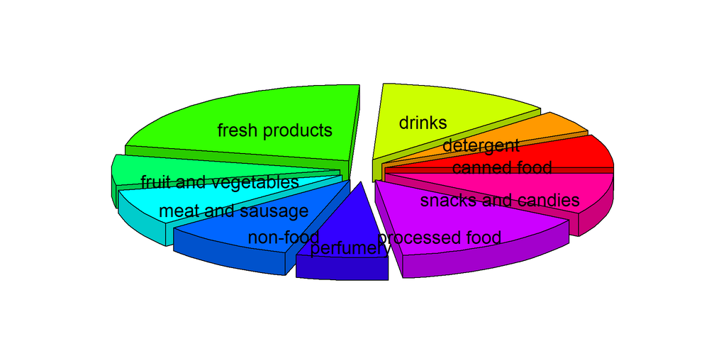

```r
category_details<-iteminfo%>%group_by(level1)%>%summarize(no_of_items=n())

pie3D(x = category_details$no_of_items,labels = category_details$level1 ,radius = 2,explode=0.2)
```

we can clearly see that there are 10 categories of products sold in these transactions and most of them are edibles:

```r
levels(category_details$level1)
```

```
##  [1] "canned food"          "detergent"            "drinks"
##  [4] "fresh products"       "fruit and vegetables" "meat and sausage"
##  [7] "non-food"             "perfumery"            "processed food"
## [10] "snacks and candies"
```

Let’s go into details and check the item labels sold in these transactions:

```r
itemLabels(Groceries)
```

```
##   [1] "frankfurter"               "sausage"
##   [3] "liver loaf"                "ham"
##   [5] "meat"                      "finished products"
##   [7] "organic sausage"           "chicken"
##   [9] "turkey"                    "pork"
##  [11] "beef"                      "hamburger meat"
##  [13] "fish"                      "citrus fruit"
##  [15] "tropical fruit"            "pip fruit"
##  [17] "grapes"                    "berries"
##  [19] "nuts/prunes"               "root vegetables"
##  [21] "onions"                    "herbs"
##  [23] "other vegetables"          "packaged fruit/vegetables"
##  [25] "whole milk"                "butter"
##  [27] "curd"                      "dessert"
##  [29] "butter milk"               "yogurt"
```

[output cut: 70 more lines]

We can plot the transactions also. For clarity of graph and for proper understanding it is better to plot a subset of dataas:

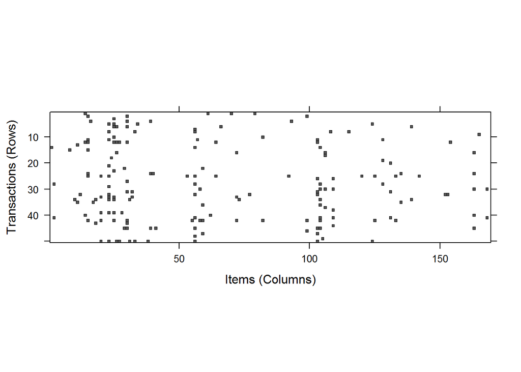

```r
plot(Groceries[1:50])
```

There are 169 products which are sold on these transactions. Let’s try the first overview over the popularity of a product by checking the frequency of the product. we will find the 10 most popular products and 10 least popular products . Top 10 products by frequency are :

```r
sort(itemFrequency(Groceries,type="absolute"),decreasing = T)[1:10]
```

```
##       whole milk other vegetables       rolls/buns             soda
##             2513             1903             1809             1715
##           yogurt    bottled water  root vegetables   tropical fruit
##             1372             1087             1072             1032
##    shopping bags          sausage
##              969              924
```

Bottom 10 products by frequency are :

```r
sort(itemFrequency(Groceries,type="absolute"),decreasing = F)[1:10]
```

```
##             baby food  sound storage medium preservation products
##                     1                     1                     2
##       kitchen utensil                  bags        frozen chicken
##                     4                     4                     6
##        baby cosmetics        toilet cleaner        salad dressing
##                     6                     7                     8
##                whisky
##                     8
```

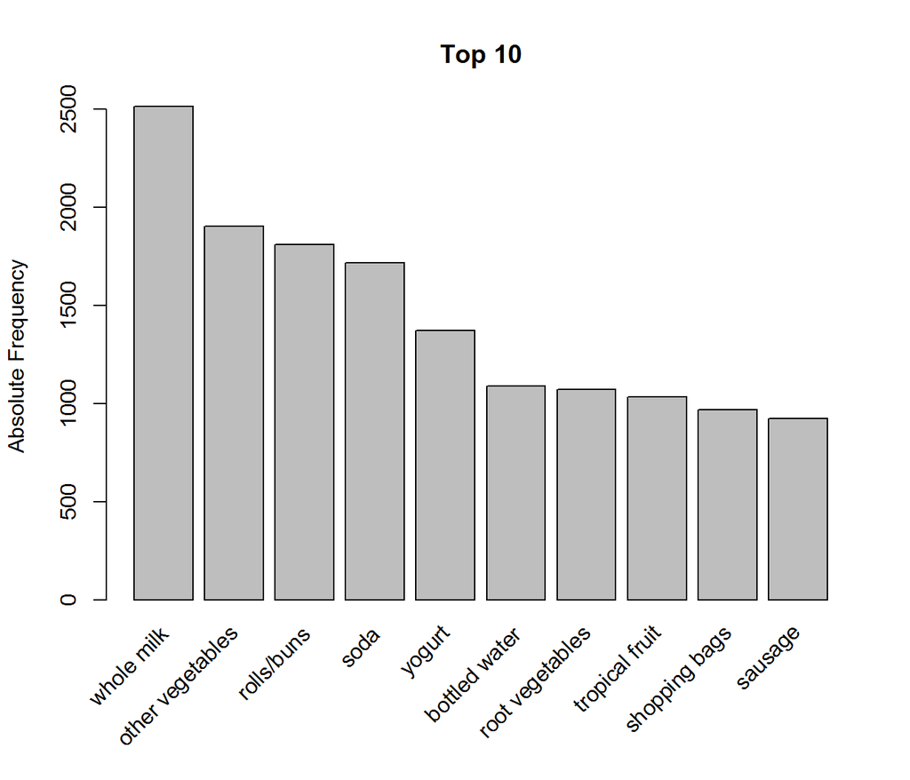

```r
itemFrequencyPlot(Groceries,topN=10,main="Top 10" , type="absolute",ylab="Absolute Frequency")
```

[figure not shown]

```r
barplot(sort(table(unlist(LIST(Groceries)))[1:10],decreasing = F),las=2 , main="Bottom 10")
```

Next obvious step would be to see the association in sales among different pairs of products and try a graphical representation :

```r
crossTable(Groceries,sort=T)[1:5,1:5]
```

```
##                  whole milk other vegetables rolls/buns soda yogurt
## whole milk             2513              736        557  394    551
## other vegetables        736             1903        419  322    427
## rolls/buns              557              419       1809  377    338
## soda                    394              322        377 1715    269
## yogurt                  551              427        338  269   1372
```

We can graphically check these items with the mosaicplot , but the limitations come to the forefront as the number of items increase in the matrix.

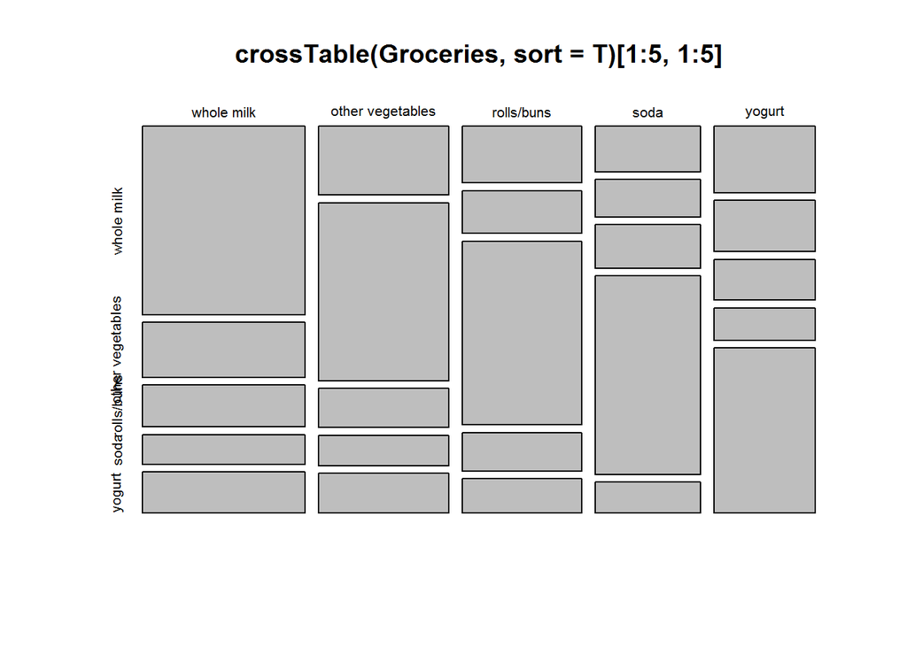

```r
mosaicplot(crossTable(Groceries,sort=T)[1:5,1:5])
```

we can find the number of transaction in which 2 items were bought together like:

```r
crossTable(Groceries)["soda","yogurt"]
```

```
## [1] 269
```

Not only can we use the count but other measures like “support”,“confidence”,“lift”,“chisquared” can also be found using the crosstable as:

```r
crossTable(Groceries,measure="support")["soda","yogurt"]
```

```
## [1] 0.0273513
```

next obvious step will be to find out a way to create more itemsets that are bought together on the transactions and to find the frequency of those itemsets as well as the other measures like support,confidence,lift and chi. we will use the arules package for this as:

```r
itemset<-apriori(Groceries,parameter = list(support=0.001,minlen=2,target="frequent"))
```

```
## Apriori
##
## Parameter specification:
##  confidence minval smax arem  aval originalSupport maxtime support minlen
##          NA    0.1    1 none FALSE            TRUE       5   0.001      2
##  maxlen            target   ext
##      10 frequent itemsets FALSE
##
## Algorithmic control:
##  filter tree heap memopt load sort verbose
##     0.1 TRUE TRUE  FALSE TRUE    2    TRUE
##
## Absolute minimum support count: 9
##
## set item appearances ...[0 item(s)] done [0.00s].
## set transactions ...[169 item(s), 9835 transaction(s)] done [0.02s].
## sorting and recoding items ... [157 item(s)] done [0.00s].
## creating transaction tree ... done [0.00s].
## checking subsets of size 1 2 3 4 5 6 done [0.02s].
## writing ... [13335 set(s)] done [0.00s].
## creating S4 object  ... done [0.00s].
```

```r
summary(itemset)
```

```
## set of 13335 itemsets
##
## most frequent items:
##       whole milk other vegetables           yogurt  root vegetables
##             3764             3341             2401             1958
##   tropical fruit          (Other)
##             1796            27683
##
## element (itemset/transaction) length distribution:sizes
##    2    3    4    5    6
## 2981 6831 3137  376   10
##
##    Min. 1st Qu.  Median    Mean 3rd Qu.    Max.
##    2.00    3.00    3.00    3.07    4.00    6.00
##
## summary of quality measures:
##     support
##  Min.   :0.001017
##  1st Qu.:0.001118
##  Median :0.001423
##  Mean   :0.002259
##  3rd Qu.:0.002237
##  Max.   :0.074835
##
## includes transaction ID lists: FALSE
##
## mining info:
##       data ntransactions support confidence
##  Groceries          9835   0.001          1
```

to find the top 10 itemsets using support as the main measure :

```r
inspect(sort(itemset,decreasing = T,by="support")[1:10])
```

```
##      items                              support
## [1]  {other vegetables,whole milk}      0.07483477
## [2]  {whole milk,rolls/buns}            0.05663447
## [3]  {whole milk,yogurt}                0.05602440
## [4]  {root vegetables,whole milk}       0.04890696
## [5]  {root vegetables,other vegetables} 0.04738180
## [6]  {other vegetables,yogurt}          0.04341637
## [7]  {other vegetables,rolls/buns}      0.04260295
## [8]  {tropical fruit,whole milk}        0.04229792
## [9]  {whole milk,soda}                  0.04006101
## [10] {rolls/buns,soda}                  0.03833249
```

to add another measure to the result e.g check lift :

```r
itemset@quality$lift<-interestMeasure(itemset,measure = "lift",transactions = Groceries)
inspect(sort(itemset,decreasing = T,by="support")[1:10])
```

```
##      items                              support    lift
## [1]  {other vegetables,whole milk}      0.07483477 1.5136341
## [2]  {whole milk,rolls/buns}            0.05663447 1.2050318
## [3]  {whole milk,yogurt}                0.05602440 1.5717351
## [4]  {root vegetables,whole milk}       0.04890696 1.7560310
## [5]  {root vegetables,other vegetables} 0.04738180 2.2466049
## [6]  {other vegetables,yogurt}          0.04341637 1.6084566
## [7]  {other vegetables,rolls/buns}      0.04260295 1.1970465
## [8]  {tropical fruit,whole milk}        0.04229792 1.5775950
## [9]  {whole milk,soda}                  0.04006101 0.8991124
## [10] {rolls/buns,soda}                  0.03833249 1.1951242
```

when we need to search for rules insted of the itemsets we change the target to the “rules” in the apriori command as :

```r
rules<-apriori(Groceries,parameter = list(support=.001,confidence=0.9,target="rules"))
```

```
## Apriori
##
## Parameter specification:
##  confidence minval smax arem  aval originalSupport maxtime support minlen
##         0.9    0.1    1 none FALSE            TRUE       5   0.001      1
##  maxlen target   ext
##      10  rules FALSE
##
## Algorithmic control:
##  filter tree heap memopt load sort verbose
##     0.1 TRUE TRUE  FALSE TRUE    2    TRUE
##
## Absolute minimum support count: 9
##
## set item appearances ...[0 item(s)] done [0.00s].
## set transactions ...[169 item(s), 9835 transaction(s)] done [0.02s].
## sorting and recoding items ... [157 item(s)] done [0.00s].
## creating transaction tree ... done [0.01s].
## checking subsets of size 1 2 3 4 5 6 done [0.00s].
## writing ... [129 rule(s)] done [0.02s].
## creating S4 object  ... done [0.00s].
```

```r
summary(rules)
```

```
## set of 129 rules
##
## rule length distribution (lhs + rhs):sizes
##  3  4  5  6
## 10 57 56  6
##
##    Min. 1st Qu.  Median    Mean 3rd Qu.    Max.
##    3.00    4.00    4.00    4.45    5.00    6.00
##
## summary of quality measures:
##     support           confidence          lift
##  Min.   :0.001017   Min.   :0.9000   Min.   : 3.522
##  1st Qu.:0.001017   1st Qu.:0.9091   1st Qu.: 3.588
##  Median :0.001017   Median :0.9167   Median : 3.669
##  Mean   :0.001139   Mean   :0.9337   Mean   : 4.216
##  3rd Qu.:0.001220   3rd Qu.:0.9333   3rd Qu.: 4.698
##  Max.   :0.001932   Max.   :1.0000   Max.   :11.235
##
## mining info:
##       data ntransactions support confidence
##  Groceries          9835   0.001        0.9
```

As with the 0.9 confidence we got 129 rules, we can inspect the top 10 after sorting with support as well as confidence:

```r
inspect(sort(rules,decreasing = T,by=c("support","confidence"))[1:10])
```

```
##      lhs                        rhs                    support confidence      lift
## [1]  {liquor,
##       red/blush wine}        => {bottled beer}     0.001931876  0.9047619 11.235269
## [2]  {tropical fruit,
##       whipped/sour cream,
##       fruit/vegetable juice} => {other vegetables} 0.001931876  0.9047619  4.675950
## [3]  {pip fruit,
##       butter,
##       whipped/sour cream}    => {whole milk}       0.001830198  0.9000000  3.522284
## [4]  {tropical fruit,
##       whipped/sour cream,
##       domestic eggs}         => {whole milk}       0.001830198  0.9000000  3.522284
## [5]  {root vegetables,
##       whipped/sour cream,
##       flour}                 => {whole milk}       0.001728521  1.0000000  3.913649
## [6]  {other vegetables,
##       cream cheese ,
##       sugar}                 => {whole milk}       0.001525165  0.9375000  3.669046
## [7]  {sausage,
##       tropical fruit,
##       root vegetables,
##       yogurt}                => {whole milk}       0.001525165  0.9375000  3.669046
## [8]  {root vegetables,
##       other vegetables,
##       yogurt,
##       oil}                   => {whole milk}       0.001423488  1.0000000  3.913649
## [9]  {citrus fruit,
##       domestic eggs,
##       sugar}                 => {whole milk}       0.001423488  0.9333333  3.652739
## [10] {yogurt,
##       domestic eggs,
##       sugar}                 => {whole milk}       0.001423488  0.9333333  3.652739
```

as we see that we have rules in the summary insted of the itemsets now with lhs and rhs shown, it is of utmost importance for business purposes to focus on the relevant rules by filtering , so that proper business decisions can be taken.

checking the items on lhs only :

```r
focus_rules1<-subset(rules,subset=(lhs%in% "yogurt"))
inspect(sort(focus_rules1,by="support",decreasing = T)[1:10])
```

```
##      lhs                   rhs                    support confidence     lift
## [1]  {sausage,
##       tropical fruit,
##       root vegetables,
##       yogurt}           => {whole milk}       0.001525165  0.9375000 3.669046
## [2]  {yogurt,
##       domestic eggs,
##       sugar}            => {whole milk}       0.001423488  0.9333333 3.652739
## [3]  {root vegetables,
##       other vegetables,
##       yogurt,
##       oil}              => {whole milk}       0.001423488  1.0000000 3.913649
## [4]  {root vegetables,
##       whole milk,
##       yogurt,
##       oil}              => {other vegetables} 0.001423488  0.9333333 4.823612
## [5]  {citrus fruit,
##       tropical fruit,
##       root vegetables,
##       whole milk,
##       yogurt}           => {other vegetables} 0.001423488  0.9333333 4.823612
## [6]  {root vegetables,
##       other vegetables,
##       yogurt,
##       rice}             => {whole milk}       0.001321810  0.9285714 3.634103
## [7]  {root vegetables,
##       whole milk,
##       yogurt,
##       rice}             => {other vegetables} 0.001321810  0.9285714 4.799002
## [8]  {beef,
##       tropical fruit,
##       yogurt,
##       rolls/buns}       => {whole milk}       0.001321810  0.9285714 3.634103
## [9]  {root vegetables,
##       other vegetables,
##       yogurt,
##       hard cheese}      => {whole milk}       0.001220132  0.9230769 3.612599
## [10] {frankfurter,
##       tropical fruit,
##       root vegetables,
##       yogurt}           => {whole milk}       0.001220132  0.9230769 3.612599
```

above inspection show us the top 10 rules by support showing the itemsets with “yogurt” in it that will result in the purchase of other items i.e.a basket full of other products with yougurt being one of them will result in purchase of what new item.This may not be that important but it will become interesting furter. Let us find the rules with whole milk and yogurt on lhs result in purchase of what on rhs.

```r
focus_rules2<-subset(rules,subset=(lhs%ain%c("yogurt","whole milk")))

inspect(sort(focus_rules2,decreasing = T,by="support")[1:5])
```

```
##     lhs                  rhs                    support confidence     lift
## [1] {root vegetables,
##      whole milk,
##      yogurt,
##      oil}             => {other vegetables} 0.001423488  0.9333333 4.823612
## [2] {citrus fruit,
##      tropical fruit,
##      root vegetables,
##      whole milk,
##      yogurt}          => {other vegetables} 0.001423488  0.9333333 4.823612
## [3] {root vegetables,
##      whole milk,
##      yogurt,
##      rice}            => {other vegetables} 0.001321810  0.9285714 4.799002
## [4] {tropical fruit,
##      grapes,
##      whole milk,
##      yogurt}          => {other vegetables} 0.001016777  1.0000000 5.168156
## [5] {tropical fruit,
##      root vegetables,
##      whole milk,
##      yogurt,
##      oil}             => {other vegetables} 0.001016777  0.9090909 4.698323
```

In fact this comes with " yogurt" and " whole milk" with other products in the basket but if we want to focys only on the person buying only these two on lhs and are interested in checking the rhs for him/her , we will have to tweak the rules as :

```r
rules_tweek<-apriori(Groceries,parameter = list(support=0.01,confidence=0.9,target="rules"),appearance = list(lhs = c("whole milk","yogurt"), default="rhs"))
```

```
## Apriori
##
## Parameter specification:
##  confidence minval smax arem  aval originalSupport maxtime support minlen
##         0.9    0.1    1 none FALSE            TRUE       5    0.01      1
##  maxlen target   ext
##      10  rules FALSE
##
## Algorithmic control:
##  filter tree heap memopt load sort verbose
##     0.1 TRUE TRUE  FALSE TRUE    2    TRUE
##
## Absolute minimum support count: 98
##
## set item appearances ...[2 item(s)] done [0.00s].
## set transactions ...[169 item(s), 9835 transaction(s)] done [0.00s].
## sorting and recoding items ... [88 item(s)] done [0.00s].
## creating transaction tree ... done [0.02s].
## checking subsets of size 1 2 3 done [0.00s].
## writing ... [0 rule(s)] done [0.00s].
## creating S4 object  ... done [0.00s].
```

```r
summary(rules_tweek)
```

```
## set of 0 rules
```

It comes with 0 rules, as there maynot be datapoints supporting this but we can check with basket containing {citrus fruit,butter,curd} on lhs for an example and check rhs:

```r
rules_tweek2<-apriori(Groceries,parameter = list(support=0.001,confidence=0.5,target="rules",minlen=4,maxlen=4),appearance = list(lhs = c("citrus fruit","butter","curd"), default="rhs"))
```

```
## Apriori
##
## Parameter specification:
##  confidence minval smax arem  aval originalSupport maxtime support minlen
##         0.5    0.1    1 none FALSE            TRUE       5   0.001      4
##  maxlen target   ext
##       4  rules FALSE
##
## Algorithmic control:
##  filter tree heap memopt load sort verbose
##     0.1 TRUE TRUE  FALSE TRUE    2    TRUE
##
## Absolute minimum support count: 9
##
## set item appearances ...[3 item(s)] done [0.00s].
## set transactions ...[169 item(s), 9835 transaction(s)] done [0.00s].
## sorting and recoding items ... [157 item(s)] done [0.00s].
## creating transaction tree ... done [0.00s].
## checking subsets of size 1 2 3 4
```

```
##  done [0.00s].
## writing ... [1 rule(s)] done [0.00s].
## creating S4 object  ... done [0.00s].
```

```r
summary(rules_tweek2)
```

```
## set of 1 rules
##
## rule length distribution (lhs + rhs):sizes
## 4
## 1
##
##    Min. 1st Qu.  Median    Mean 3rd Qu.    Max.
##       4       4       4       4       4       4
##
## summary of quality measures:
##     support           confidence          lift
##  Min.   :0.001118   Min.   :0.9167   Min.   :3.588
##  1st Qu.:0.001118   1st Qu.:0.9167   1st Qu.:3.588
##  Median :0.001118   Median :0.9167   Median :3.588
##  Mean   :0.001118   Mean   :0.9167   Mean   :3.588
##  3rd Qu.:0.001118   3rd Qu.:0.9167   3rd Qu.:3.588
##  Max.   :0.001118   Max.   :0.9167   Max.   :3.588
##
## mining info:
##       data ntransactions support confidence
##  Groceries          9835   0.001        0.5
```

now we have 1 rule and we can inspect those as :

```r
inspect(rules_tweek2)
```

```
##     lhs                           rhs          support     confidence
## [1] {citrus fruit,butter,curd} => {whole milk} 0.001118454 0.9166667
##     lift
## [1] 3.587512
```

Clearly it tells us that these 3 products together can lead to buying the 4th product " whole milk" .we have that happening on 9 out of 10 transactions like that . although the %age of such transactions in the total transactions is low. as the lift is high , putting these 3 products together may induce the customer to buy the 4th .

Now we come to the stage of graphically showing the rules in the form of a network diagram where inputs(lhs) are incoming arrows to the circle and the outputs(rhs) are outgoing arrows. It may not be clear from whole rules graph ,but we will filter down to understand:

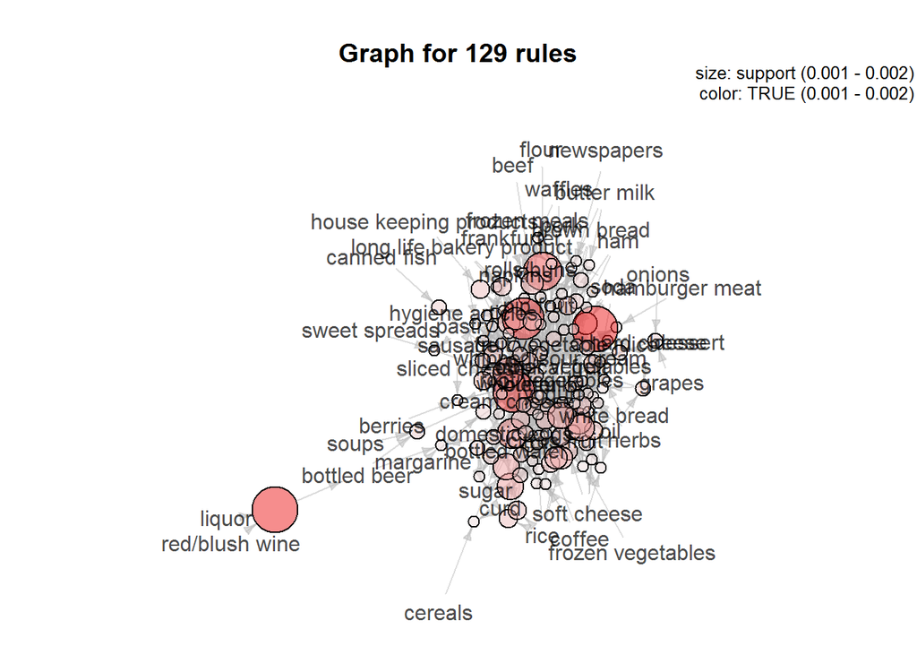

```r
plot(rules,method = "graph",shading = T)
```

using the same on a subset of rules:

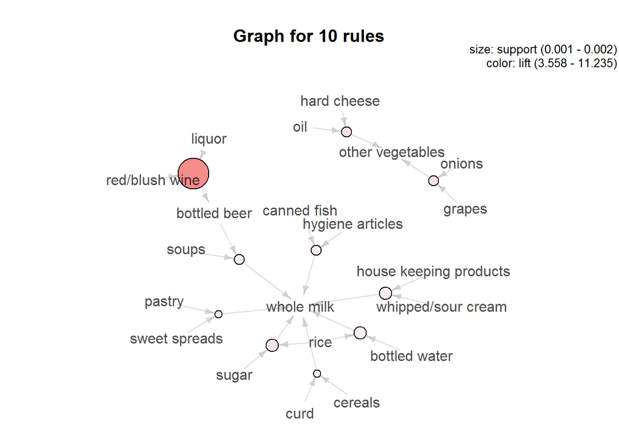

```r
plot(rules[1:10],method = "graph",shading = "lift")
```

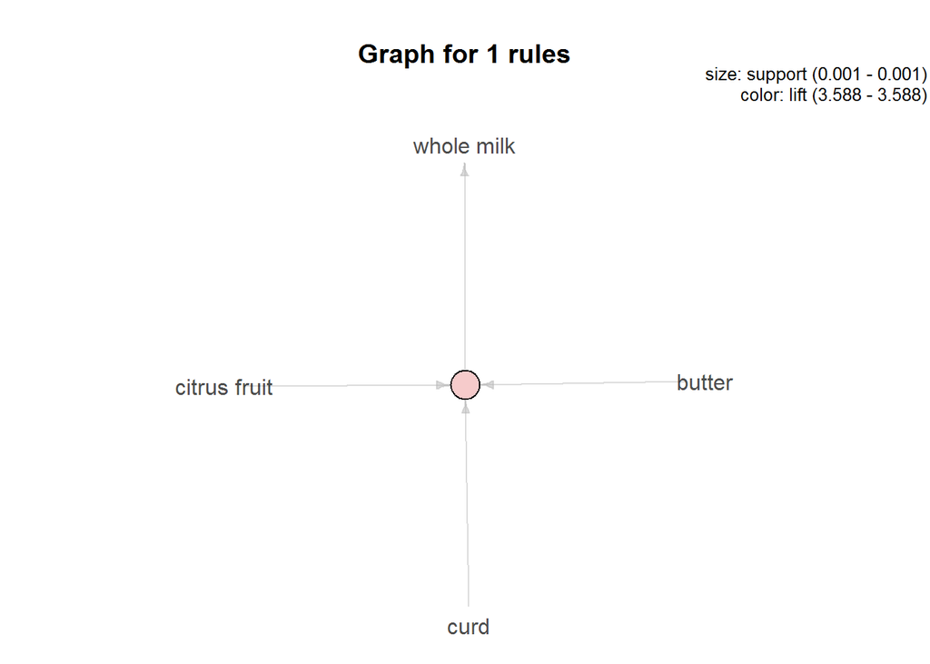

```r
plot(rules_tweek2,method = "graph",shading = "lift")
```

Another way to plot the rules is the following . This is useful , if you want to drill down the rules based on the graph and then analyse further. For this you need to use the interactive part of the plot.

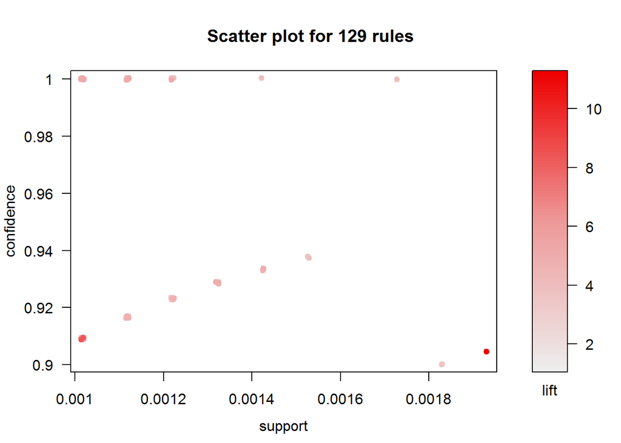

```r
plot(rules)
```

Conclusion:

Although from the analysis of Market basket analysis , it seems like a tool to help retailers ( online or brick) to help them in cross selling, Product placement,Affinity Promotion, fraud detection or customer behavior, but in fact it is an indespensible tool for a data scientist as it is basically and association analysis. By identifying itemsets or set of inputs, we can after analysis safely forecast the outcome with probability of happening mentioned alongside.